# Assignment1_v2

### 1. What is our independent variable? What is our dependent variable?

**Independent variable**: This is a variable that can be operated for an experiment so as to see the influences on a dependent variable. It is also called experimental or predictor variable. Therefore, in the Stroop task, the independent variable would be congruent and incongruent conditions. For both conditions, colours and colour-word pairs can be varied. Also, participants can be grouped into ages, their jobs in order to observe more detailed effects on those groups.

**Dependent variable**: This is occasionally called an outcome variable, and for the Stroop task, it would be the time that the participants pronounce colours of the inks on both tasks.

### 2. What is an appropriate set of hypotheses for this task? What kind of statistical test do you expect to perform? Justify your choices.

In the human brain, the information process for a reading alphabet will have a priority than that for a colour information. In other words, processing a colour information in the human brain will have more steps than reading alphabets, then people will spend more time to say out "the colours of the inks in which the word is printed" on incongruent words than that on congruent words.

Using hypothesis text, it can be determined that how a large amount of effects on a sample of data would have a certain condition on the entire population.

$\mu_C$ denotes the mean of the congruent words dataset, and $\mu_I$ represents the mean of the incongruent words dataset.

**Null Hypothesis** $H_0: \mu_I=\mu_C$, which means people will not be affected by incongruent words task.

**Alternative Hypothesis** $H_a: \mu_I > \mu_C$, which means that people tend to have more time to finish incongruent words task than congruent words task.

### 3. Report some descriptive statistics regarding this dataset. Include at least one measure of central tendency and at least one measure of variability.

Below is a table of Mean, Standard Deviation, and Median for both sample dataset.

[output not shown]

### 4. Provide one or two visualizations that show the distribution of the sample data. Write one or two sentences noting what you observe about the plot or plots.

People tend to take more time to finish the task on the incongruent words than that on the congruent words. In addition, it became wider for the standard deviation of incongruent task than that of congruent task. Though the above table tells some descriptive statistics, it is hard to identify whether the hypothesis is significant or not, as well as which kind of central tendency has more appropriate descriptive statistics for each dataset.

Therefore, it is better to plot a histogram for each dataset so as to find the most descriptive one.

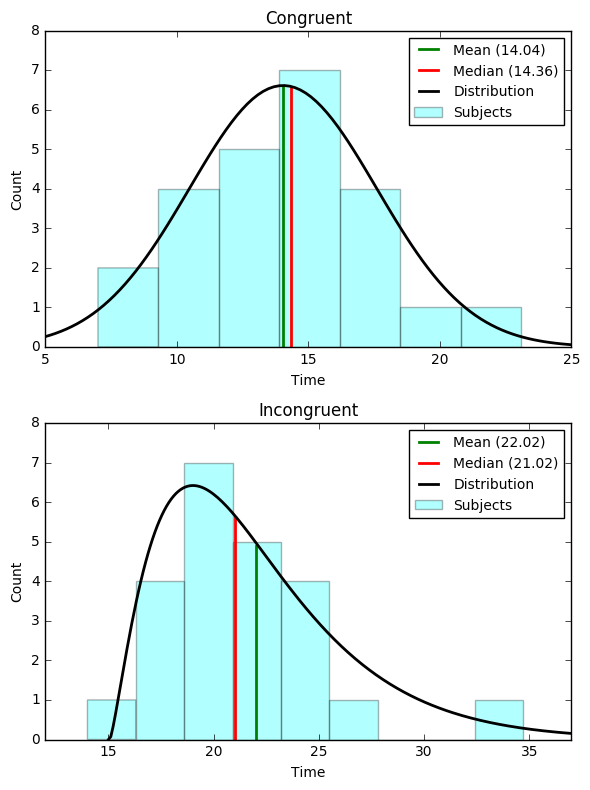

```python
import pandas as pd
import numpy as np
from scipy import stats
import matplotlib.pyplot as plt
%matplotlib inline

data = pd.read_csv("HW1_dataset.csv")

data = data.drop('Unnamed: 0', axis=1)

fig, ax = plt.subplots(2, 1, figsize = [6, 8])
x_range = np.ones(100)

#####################
## Congruent words ##
#####################

## Histogram
c_min = np.round(np.min(data['Congruent'])) - 2
c_max = np.round(np.max(data['Congruent'])) + 2
c_range = np.arange(c_min, c_max, 2.3)
# print(c_range)

ax[0].hist(data['Congruent'], bins = c_range, color='Cyan', alpha=0.3, label='Subjects')
ax[0].set_title('Congruent')
ax[0].set_xlim(5, 25)
ax[0].set_ylim(0, 8)

## Mean, Median, Mode
c_mean = 14.04
c_std = 3.56
c_median = 14.36

y_mean_range = np.linspace(0, 6.6, 100)
ax[0].plot(x_range*c_mean, y_mean_range, '-', c='g', linewidth = 2, label="Mean (14.04)")
y_median_range = np.linspace(0, 6.55, 100)
ax[0].plot(x_range*c_median, y_median_range, '-', c='r', linewidth = 2, label="Median (14.36)")

## Distribution
c_tickRange = np.linspace(5, 25, 100)
c_pdf = stats.norm.pdf(c_tickRange, c_mean, c_std) * 59 # now get theoretical values in our interval
ax[0].plot(c_tickRange, c_pdf, c='black', label="Distribution", linewidth = 2)

## Labels
ax[0].set_xlabel('Time')
ax[0].set_ylabel('Count')
ax[0].legend(loc='best', fontsize=10)

#######################
## Incongruent words ##
#######################

## Histogram
i_min = np.round(np.min(data['Incongruent'])) - 2
i_max = np.round(np.max(data['Incongruent'])) + 2
i_range = np.arange(i_min, i_max, 2.3)
# print(i_range)

ax[1].hist(data['Incongruent'], bins = i_range, color='Cyan', alpha=0.3, label='Subjects')
ax[1].set_title('Incongruent')
ax[1].set_xlim(12, 37)
ax[1].set_ylim(0, 8)

## Mean, Median, Mode
i_mean = 22.02
i_median = 21.02
y_mean_range = np.linspace(0, 4.9, 100)
ax[1].plot(x_range*i_mean, y_mean_range, '-', c='g', linewidth = 2, label='Mean (22.02)')
y_median_range = np.linspace(0, 5.6, 100)
ax[1].plot(x_range*i_median, y_median_range, '-', c='r', linewidth = 2, label='Median (21.02)')

## Distribution
i_tickRange = np.linspace(15, 37, 200)
ag,bg,cg = stats.gamma.fit(data['Incongruent'])
pdf_gamma = stats.gamma.pdf(i_tickRange, ag, bg,cg) * 59
ax[1].plot(i_tickRange, pdf_gamma, c='black', label="Distribution", linewidth = 2)

## Labels
ax[1].set_xlabel('Time')
ax[1].set_ylabel('Count')
ax[1].legend(loc='best', fontsize=10)

fig.tight_layout()
```

The histogram of the congruent words dataset has 7 bins with 2.3 bin size, and it looks like a normal distribution. Theoretically, the mean, median, and mode of its sample dataset should be the same value.

However, though incongruent words dataset has the same bin size, 2.3, as the congruent histogram with 9 bins, it seems a positive skewed distribution with one outlier bin and it has an influence the incongruent mean value. The green line (mean value) is slightly on right to the red line (median value). Therefore, IQR must be checked by boxplot to be convinced with the most appropriate kind of central tendency.

[figure not shown]

```python
fig, ax = plt.subplots(1, 1, figsize = [7, 5])

x_range = np.linspace(1, 2, 100)

i_IQR = ax.boxplot(data['Incongruent'])
i_boxes = i_IQR['boxes'][0].get_data()[1]

y_Q1 = np.ones(100) * 18.71675
ax.plot(x_range, y_Q1, '-.', linewidth=0.5, c='black')

y_Q2 = np.ones(100) * 24.0515
ax.plot(x_range, y_Q2, '-.', linewidth=0.5, c='black')

y_Min = np.ones(100) * 15.687
ax.plot(x_range, y_Min, '-.', linewidth=0.5, c='black')

y_Max = np.ones(100) * 26.282
ax.plot(x_range, y_Max, '-.', linewidth=0.5, c='black')

ax.text(1.34, 15.9, 'Min (15.69)')
ax.text(1.35, 19, 'Q1 (18.72)')
ax.text(0.73, 20.7, 'Median (21.02)', color='r')
ax.text(1.35, 24.3, 'Q2 (24.05)')
ax.text(1.33, 26.5, 'Max (26.28)')
ax.set_xticks([])
ax.set_title('Box Plot for Incongruent Dataset')
```

### 5. Now, perform the statistical test and report your results. What is your confidence level and your critical statistic value? Do you reject the null hypothesis or fail to reject it? Come to a conclusion in terms of the experiment task. Did the results match up with your expectations?

- The diffence (Incongruent - Congruent) between two dataset is as below:

| Congruent (x_i) | Incongruent (y_i) | Difference (d_i) |
| --- | --- | --- |
| 12.079 | 19.278 | 7.199 |
| 16.791 | 18.741 | 1.950 |
| 9.564 | 21.214 | 11.650 |
| 8.630 | 15.687 | 7.057 |
| 14.669 | 22.803 | 8.134 |
| 12.238 | 20.878 | 8.640 |
| 14.692 | 24.572 | 9.880 |
| 8.987 | 17.394 | 8.407 |
| 9.401 | 20.762 | 11.361 |
| 14.480 | 26.282 | 11.802 |
| 22.328 | 24.524 | 2.196 |
| 15.298 | 18.644 | 3.346 |
| 15.073 | 17.510 | 2.437 |
| 16.929 | 20.330 | 3.401 |
| 18.200 | 35.255 | 17.055 |
| 12.130 | 22.158 | 10.028 |
| 18.495 | 25.139 | 6.644 |
| 10.639 | 20.429 | 9.790 |
| 11.344 | 17.425 | 6.081 |
| 12.369 | 34.288 | 21.919 |
| 12.944 | 23.894 | 10.950 |
| 14.233 | 17.960 | 3.727 |
| 19.710 | 22.058 | 2.348 |
| 16.004 | 21.157 | 5.153 |

[figure not shown]

```python
import pandas as pd
import numpy as np
from scipy import stats
import matplotlib.pyplot as plt
%matplotlib inline

mean = 7.98
std = 0.79

t_critical = np.ones(100) * 1.714
t_statistics = np.ones(100) * 23.41
y = np.linspace(0, 0.6, 100)

plt.plot(t_critical, y, c='r', linewidth=2)
plt.plot(t_statistics, y, c='b', linewidth=2)

# Distribution
tickRange = np.linspace(-10, 30, 1000)
c_pdf = stats.norm.pdf(tickRange, 0, std)
plt.plot(tickRange, c_pdf, c='black', label="Distribution", linewidth = 2)

plt.title('Result')
plt.text(2.1, 0.5, 't critical (1.714)', color='red')
plt.text(12, 0.3, 't statistics (23.41)', color='blue')
```

Therefore, the result is significant and reject hypothesis. This match up with the assumption that 'the information process for a reading alphabets will have a priority than that for a colour information'.